# Лабораторная работа № 6

Управление процессами

Павличенко Родион Андреевич

1132246838@pfur.ru

Российский университет дружбы народов

# Информация

## Докладчик

- Павличенко Родион Андреевич
- Cтудент
- Группа НПИбд-02-24
- Российский университет дружбы народов им. П. Лумумбы
- 1132246838@pfur.ru

# Выполнение лабораторной работы

## Получили полномочия администратора.Ввели следующие команды: sleep 3600 &; dd if=/dev/zero of=/dev/null &; sleep 7200. Ввели Ctrl + z , чтобы остановить процесс. Ввели jobs. Мы увидили три задания, которые мы только что запустили. Первые два имеют состояние Running, а последнее задание в настоящее время находится в состоянии Stopped. Для продолжения выполнения задания 3 в фоновом режиме ввели bg 3. С помощью команды jobs посмотрели изменения в статусе заданий.

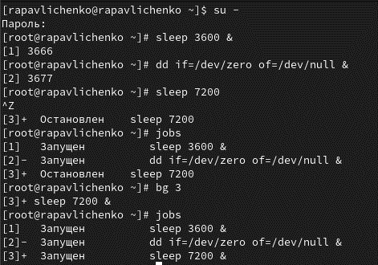

Рисунок 1: Создание процессов

## Для перемещения задания 1 на передний план ввели fg 1. Ввели Ctrl + c , чтобы отменить задание 1. С помощью команды jobs посмотрели изменения в статусе заданий. Проделали то же самое для отмены заданий 2 и 3.

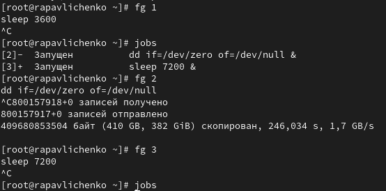

Рисунок 2: Работа с процессами

## Открыли второй терминал и под учётной записью своего пользователя ввели в нём: dd if=/dev/zero of=/dev/null & 10. Ввели exit, чтобы закрыть второй терминал.

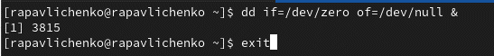

Рисунок 3: Работа во втором терминале

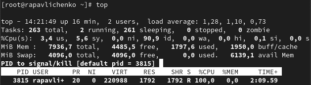

Рисунок 4: Команда top

## Получили полномочия администратора su - Ввели следующие команды: dd if=/dev/zero of=/dev/null &; dd if=/dev/zero of=/dev/null &; dd if=/dev/zero of=/dev/null &

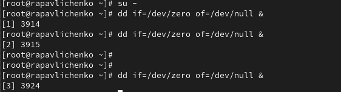

Рисунок 5: Cоздание процессов

## Ввели ps aux | grep dd. Это показало все строки, в которых есть буквы dd. Использовали PID одного из процессов dd, чтобы изменить приоритет. Ввели ps fax | grep -B5 dd

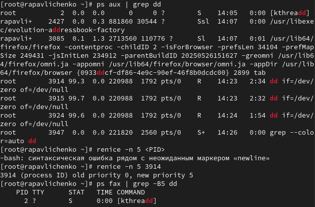

Рисунок 6: Строки, где есть буквы dd

## Нашли PID корневой оболочки, из которой были запущены процессы dd, и ввели kill -9 (заменив на значение PID оболочки). Мы увидели, что наша корневая оболочка закрылась, а вместе с ней и все процессы dd

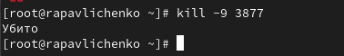

Рисунок 7: Уничтожение процесса

## Запустили команду dd if=/dev/zero of=/dev/null трижды как фоновое задание. Увеличили приоритет одной из этих команд, используя значение приоритета -5

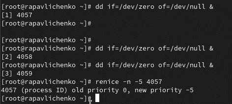

Рисунок 8: Задание 1

## Изменили приоритет того же процесса ещё раз, но использовали на этот раз значение −15. Завершили все процессы dd, которые мы запустили.

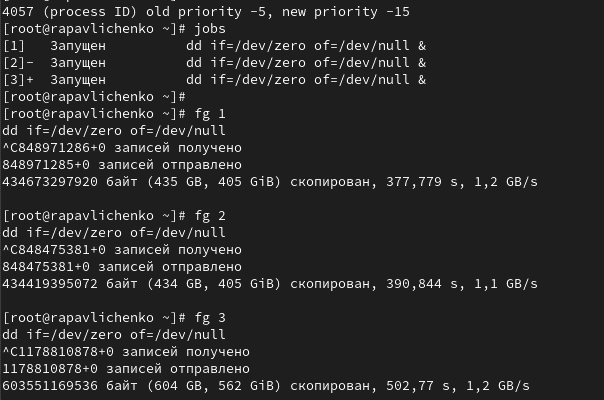

Рисунок 9: Задание 1

## Запустили программу yes в фоновом режиме с подавлением потока вывода. Запустили программу yes на переднем плане с подавлением потока вывода. Приостановили выполнение программы. Заново запустили программу yes с теми же параметрами, затем завершили её выполнение. Запустили программу yes на переднем плане без подавления потока вывода. Приостановили выполнение программы.

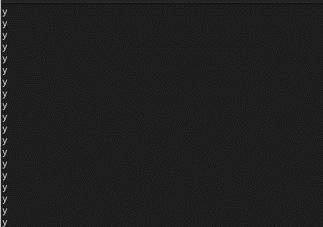

Рисунок 10: Задание 2

## Проверили состояния заданий, воспользовавшись командой jobs. Перевели процесс, который у нас выполнялся в фоновом режиме, на передний план, затем остановили его.

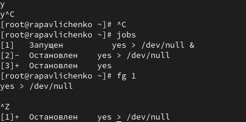

Рисунок 11: Задание 2

## Запустили процесс в фоновом режиме таким образом, чтобы он продолжил свою работу даже после отключения от терминала. Закрыли окно и заново запустили консоль. Убедились что процесс продолжил свою работу.

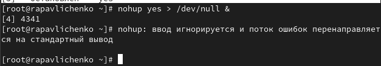

Рисунок 12: Задание 2

## Получили информацию о запущенных в операционной системе процессах с помощью утилиты top. Запустили ещё три программы yes в фоновом режиме с подавлением потока вывода

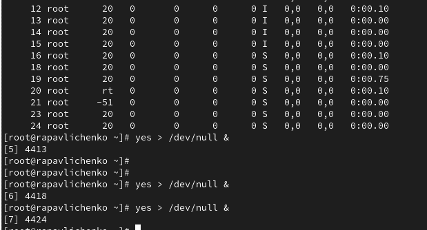

Рисунок 13: Задание 2

## Запустили ещё три программы yes в фоновом режиме с подавлением потока вывода. Убили два процесса: для одного использовали его PID, а для другого — его идентификатор конкретного задания. Попробовали послать сигнал 1 (SIGHUP) процессу, запущенному с помощью nohup, и обычному процессу. Запустили ещё несколько программ yes в фоновом режиме с подавлением потока вывода. Завершили их работу одновременно, используя команду killall

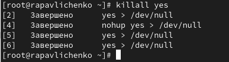

Рисунок 14: Задание 2

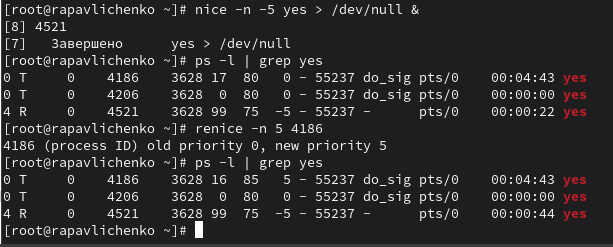

Рисунок 15: Задание 2